# Group 6 Week 5 Unsupervised Learning

Thomas DeWaters

4/16/2022

## Introduction

Clustering is an unsupervised machine learning approach for discovering and grouping related data points in data sets without regard for the end result. In this case we are going to run different clustering methods on the Heart data set to see what population groups are formed. Specifically I will be trying the following methods: K-Means, K-Medoids and Hierarchical Clustering. I will determine the ideal number of clusters for each method using the Gap Statistic. It is important to note that while we have determined that three categories of cholesterol levels are appropriate based on common medical advice, that does not mean we will form the same number of clusters utilizing the Gap Statistic.

## Data Preparation

The first step of our analysis is to prepare our data for clustering. We Will:

- Load our data into RStudio
- Assign cholesterol level categories
- Create a subset of only our predictors
- Center and scale our predictor data to avoid issues with vastly different data scales.
- Perform PCA to see if it is worth using as a dimension reduction tool

#### Assigning Our Cholesterol Categories

We will use the following values to assign our cholesterol level categories

| Category | Cholesterol Level |
| --- | --- |
| Desirable | Chol < 200 |
| Borderline | 200 <= Chol < 240 |
| High | Chol >= 240 |

#### Subsetting Data and Scaling Predictors

We will select only the predictors we are interested in using, this means removing two columns, target (categorical variable determining if the original subject had increased risk for heart disease) and orig.cat (our original category labels from above that we are comparing our clusters against.) This is because we are using an unsupervised machine learning method and we do not want to include outcome categories in our clustering efforts.

#### Principal Component Analysis

PCA (Principal Component Analysis) is a dimension reduction method that reduces the number of predictors while retaining as much information about the data set as possible. This is accomplished by computing each Principal Component (PC), in our case using Singular Value Decomposition. We will the produce a Scree plot, which is a plot of how much variation each PC explains within the data.

First we will calculate each PC and the amount of variance explained by each PC

Then we can plot the variance explained against the PC to see if there are any obvious cutoffs on how many PC’s would provide ample explanation of our data sets variance.

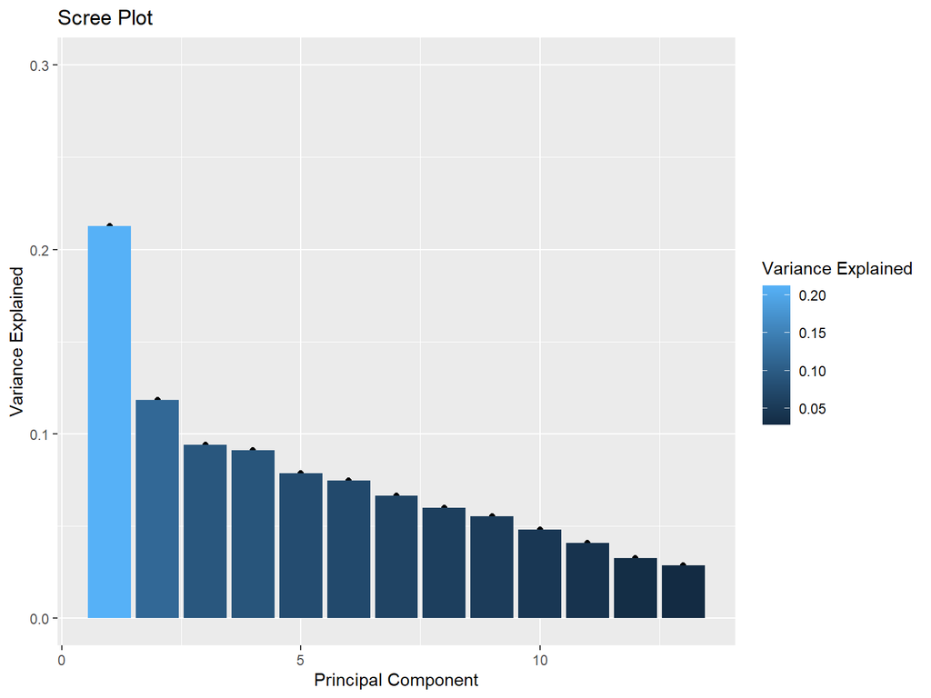

Table 1: Cumulative Variance Proportion

|  | PC1 | PC2 | PC3 | PC4 | PC5 | PC6 | PC7 | PC8 | PC9 | PC10 | PC11 | PC12 | PC13 |
| --- | --- | --- | --- | --- | --- | --- | --- | --- | --- | --- | --- | --- | --- |
| Standard deviation | 1.662 | 1.240 | 1.106 | 1.087 | 1.011 | 0.985 | 0.929 | 0.881 | 0.848 | 0.788 | 0.728 | 0.650 | 0.610 |
| Proportion of Variance | 0.213 | 0.118 | 0.094 | 0.091 | 0.079 | 0.075 | 0.066 | 0.060 | 0.055 | 0.048 | 0.041 | 0.033 | 0.029 |
| Cumulative Proportion | 0.213 | 0.331 | 0.425 | 0.516 | 0.594 | 0.669 | 0.735 | 0.795 | 0.850 | 0.898 | 0.939 | 0.971 | 1.000 |

Looking at Table 1, we can see that we would need to use 11 PC’s to account for over 90% of the variance in the data. Given that we have 13 total PCs, reducing to 11 PCs does not help us computationally very much, and we lose ~10% of our data set variance. In this case, I have decided to not use PCA to reduce dimensionality of our data set.

## Clustering Methods

#### K-Means Clustering

K-Means clustering is an example of partitional clustering. The algorithm randomly chooses a centroid for each cluster(mean of cluster), and in a iterative fashion moves through each of the points until each cluster has minimized intra-cluster distance and maximized inter-cluster distance. K-means assumes the variance of each attribute is spherical, the prior probability for all k clusters is the same (each cluster has roughly the same number of observations) and all variables have the same variance.

Table 2: Count of Cholesterol Category

| Cholesterol Category | Frequency |
| --- | --- |
| Borderline | 98 |
| Desirable | 50 |
| High | 155 |

K-Means clustering has some advantages, mainly it scales well to large data sets it is simple to implement, guarantee convergence and it generalizes well to clusters that are different shapes and sizes. There are also some downsides to K-means clustering, mainly it is sensitive to outliers since it relies on the mean as a measure of central tendency which is sensitive to extreme values. We must also manually define “k”, the number of clusters. While we can use the Gap Statistic to help determine the ideal number, this still can negatively affect the outcome if we choose wrong for our data set.

First we will calculate the Gap Statistic and visualize the optimal number of clusters

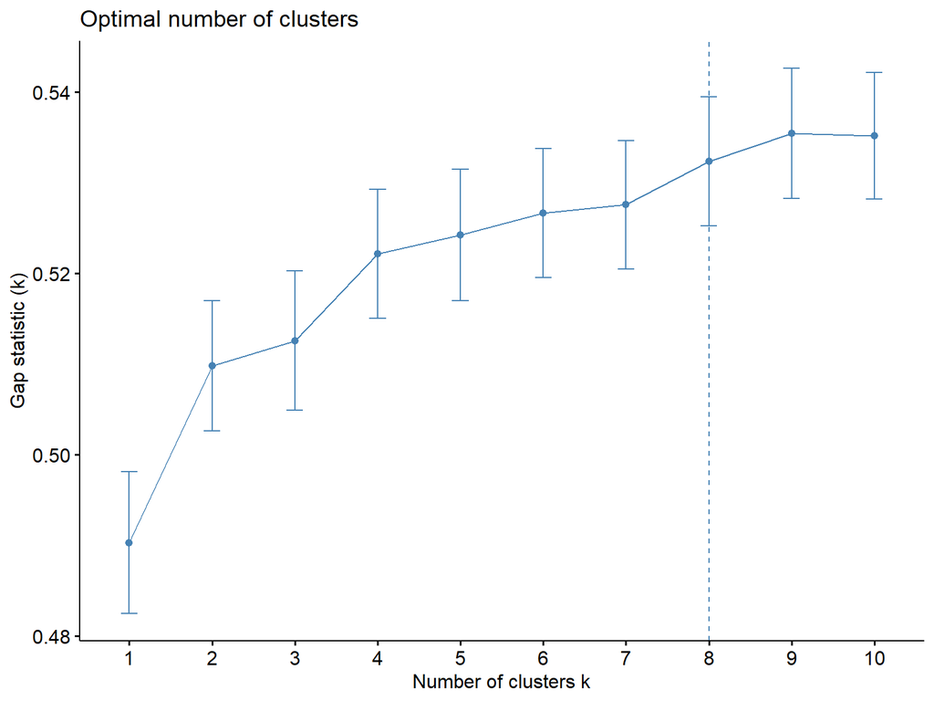

Figure 2: Looking at the above Gap Statistic chart, we can see that 8 is the ideal number for “k”, so we will use that in our K-Means clustering algorithm.

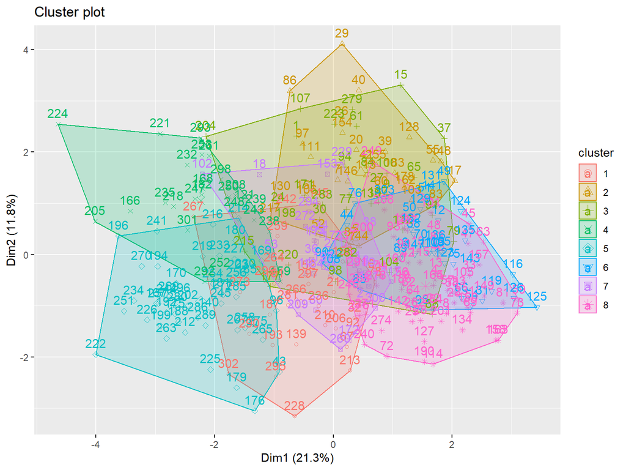

Figure 3: The above plot of the clusters is created in 2 dimensions using the first two PCs for visualization purposes. As we can see, we do not exactly have defined easily separable clusters. It is also important to note that we have identified 8 clusters with the Gap Statistic, but medically we are only using 3 groupings of serum cholesterol levels. We will add this to our data set above and move to our next clustering algorithm.

#### K-Medoids

K-Medoids clustering is an example of partitional clustering. The algorithm randomly chooses a centroid for each cluster(it is always an actual data point), and in a iterative fashion moves through each of the points until each cluster has minimized intra-cluster distance and maximized inter-cluster distance. The largest difference from K-medoids and K-means clustering is that K-means chooses a center of the cluster based on the mean of the data points, and it may not really be a data point, K-medoids always selects a datapoint in the data set to be the center of the cluster and it is based on the median.

K-medoids has all of the same advantages and disadvantages of K-means clustering with one notable exception, it is not sensitive to outliers because it uses the median, a measure of central tendency that is not sensitive to extreme values, to choose the center of the cluster. This results in the algorithm being robust to both outliers and noise in the data, making it more practical to real-world data.

First we will calculate the Gap Statistic and visualize the optimal number of clusters

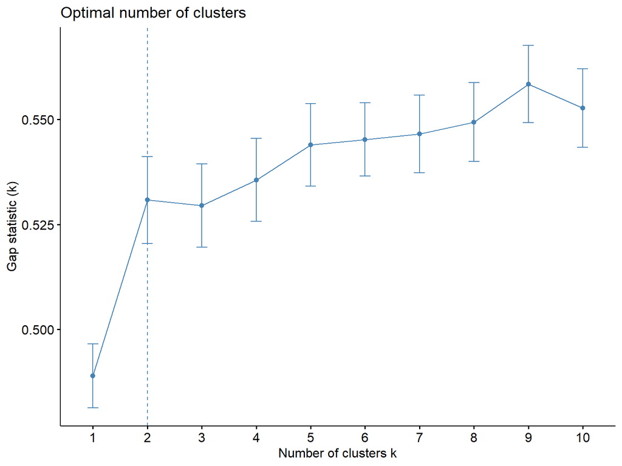

Figure 4: Looking at the above Gap Statistic chart, we can see that 2 is the ideal number for “k”, so we will use that in our K-Medoids clustering algorithm.

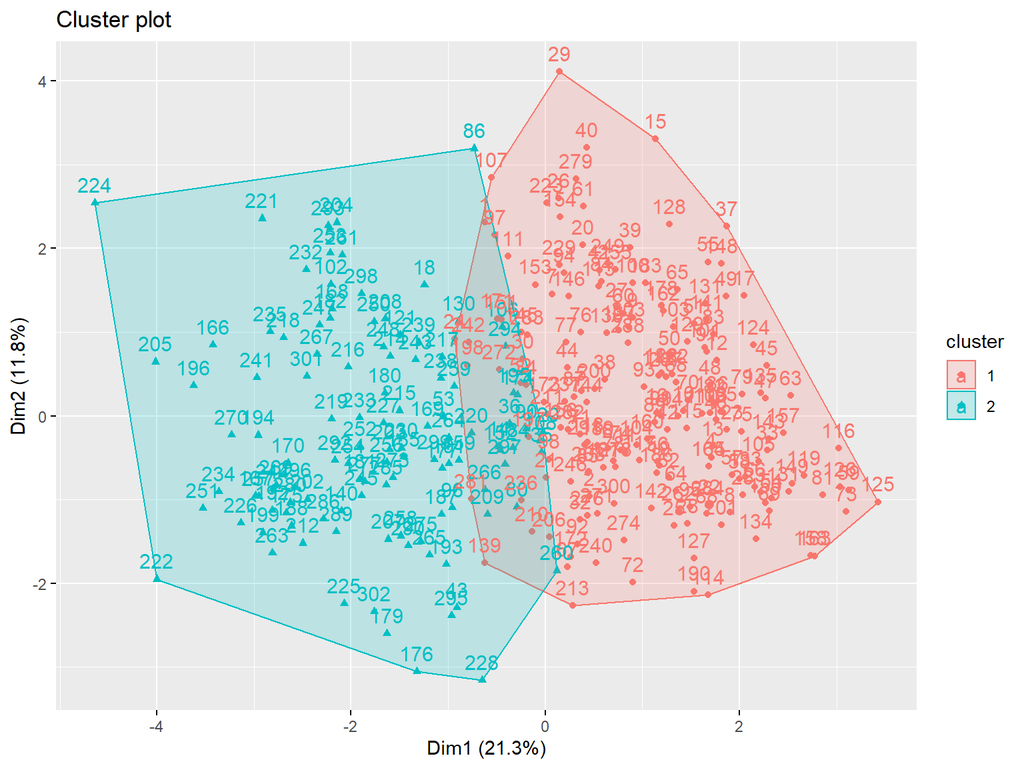

Figure 5: The above plot of the clusters is created in 2 dimensions using the first two PCs for visualization purposes. As we can see, we have two largely separable clusters. This may be attributed to K-medoids ability to handle outliers and noise within the data better than K-means. It is also important to note that we have identified 2 clusters with the Gap Statistic, but medically we are using 3 groupings of serum cholesterol levels. We will add this to our data set above and move to our next clustering algorithm.

#### Hierarchical Clustering

Hierarchical clustering is a method of clustering data that starts with each data point being its own cluster, and merges the most similar data points in each round, creating a cluster. This is repeated at each level of the cluster until there is only a single cluster. As it moves through each level, it creates a hierarchy of clusters, hence the name. There are two types of hierarchical clustering, agglomerative (starts at the bottom and works towards the top) and divisive (starts at the top and works towards the bottom). I have chosen to use agglomerative clustering in the below example.

Hierarchical clustering outputs a hierarchy, which is a structure and that is more informative than the unstructured set of clusters output by K-Means and K-Medoids. It is easier to decide on the number of clusters as you can look at the dendrogram. It is also relatively easy to implement. There are three main disadvantages of Hierarchical clustering, the method is very computationally expensive and does not scale well, it is very sensitive to outliers, and the order of the data has an impact on the final results obtained.

First we will calculate the agglomerative coefficient for each clustering linkage method to decide on which to utilize.

Table 3: Agglomerative Coefficent of Linkage Methods

|  | Coefficent |
| --- | --- |
| average | 0.704 |
| single | 0.545 |
| complete | 0.773 |
| ward | 0.923 |

Figure 6: Looking at the above table we can see that ward linkage significantly outperforms the nearest method at 0.923 vs. 0.773 for complete. So we will use ward linkage going forward.

After performing hierarchical clustering using ward linkage, we have the below dendrogram.

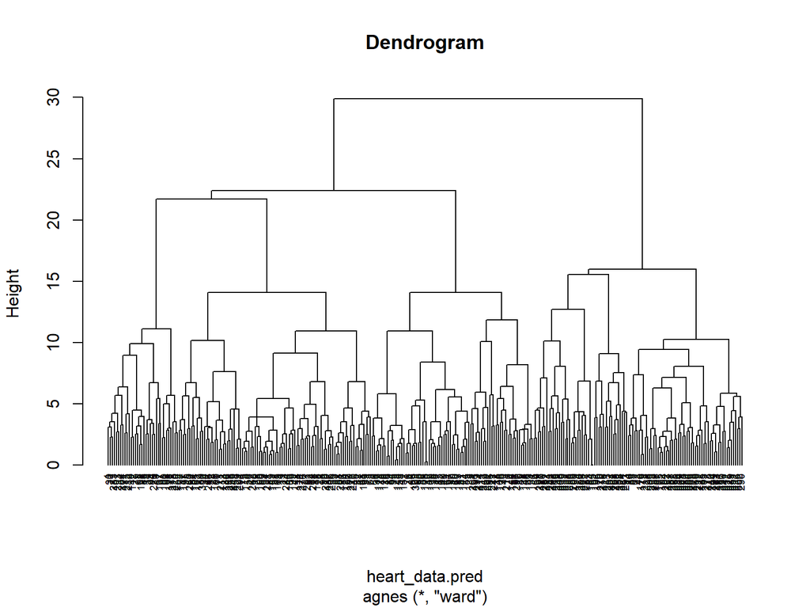

Figure 7: Hierarchical clustering using Ward’s minimum variance dendrogram.

We will then calculate the Gap Statistic and visualize the optimal number of clusters

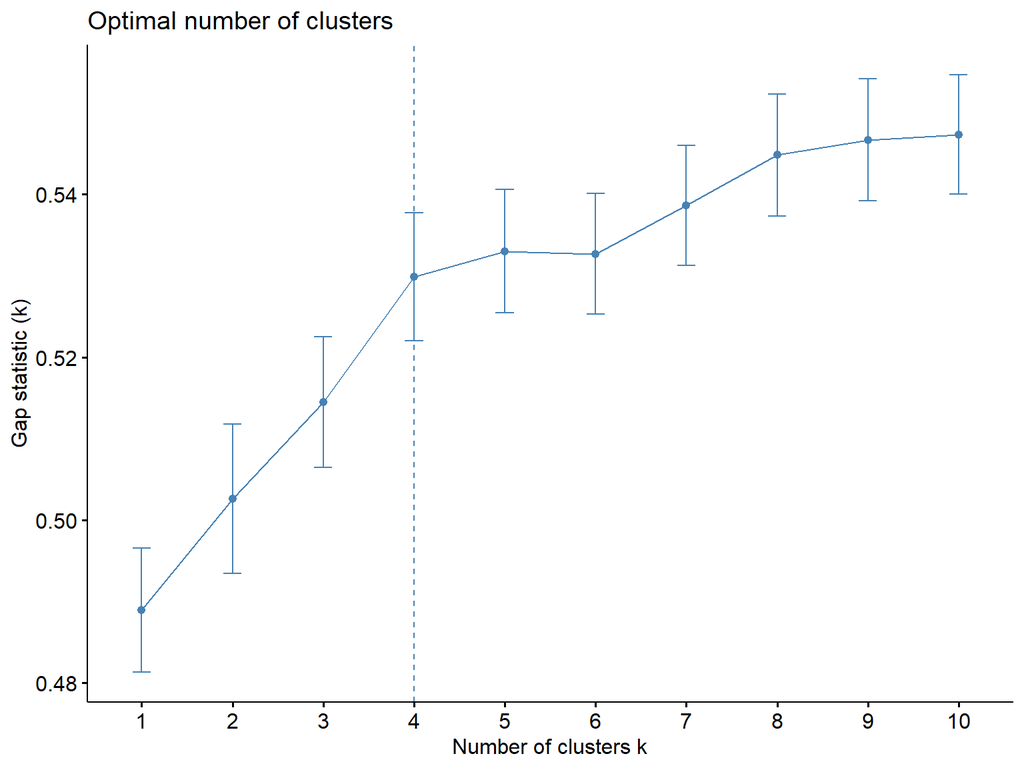

Figure 8: Looking at the above Gap Statistic chart, we can see that 4 is the ideal number for “k”, so we will use that in our Hierarchical clustering algorithm.

When calculating Hierarchical clustering with 4 clusters, we are also going to calculate the euclidean distance matrix for the heart predictor data set and pass that to the clustering function. This will produce the below dendrogram. We can see the height is cut at ~19 to produce the clusters.

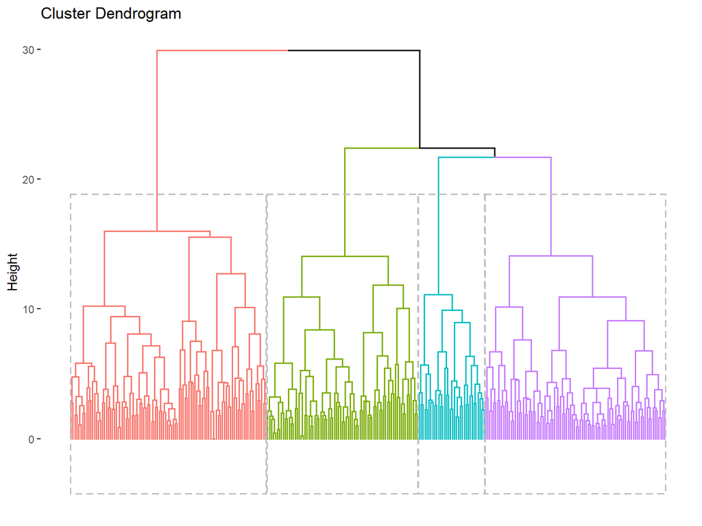

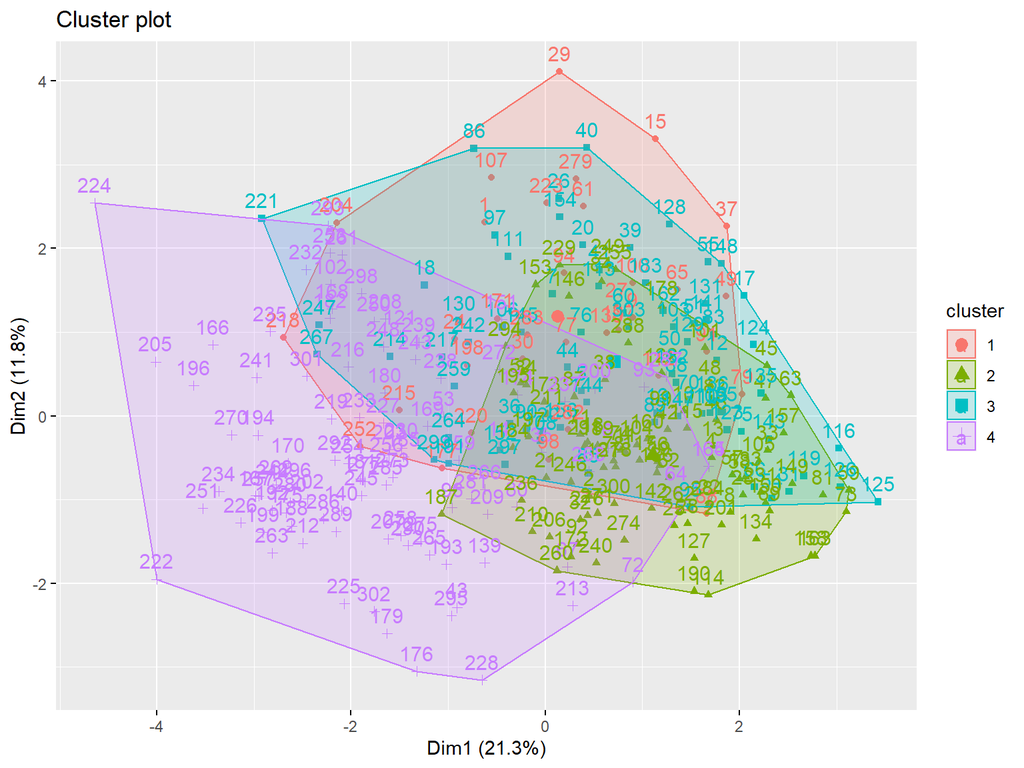

## Method Comparisons

As mentioned in the introduction, clustering analysis is an unsupervised machine learning method, this means that we do not start with a target in mind, but look for patterns in the data. Given that we already have targets in the data, we are going to look for similarities with the original categories that were used, and the different clusters that were produced with the above 3 methods.

### Orignial Clusters

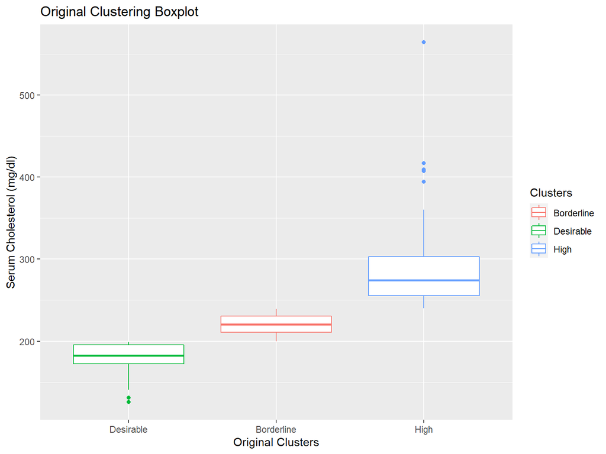

Figure 10: Above we can see the box plot of the original clusters using the medical definition cited earlier in the paper. We can see a very clear delineation between the desirable cluster, and the borderline and high clusters.

### K-Means Clusters

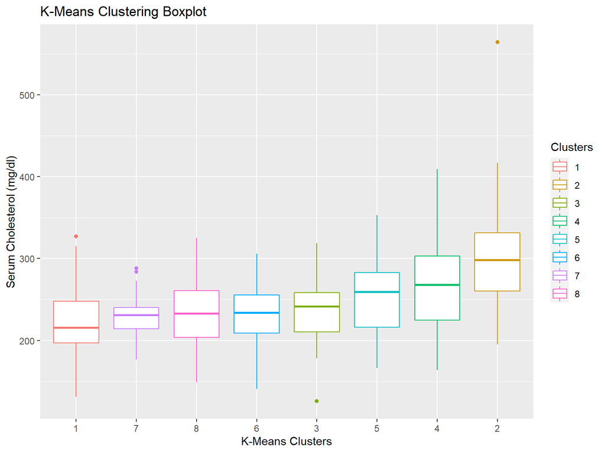

### K-Medoids Clusters

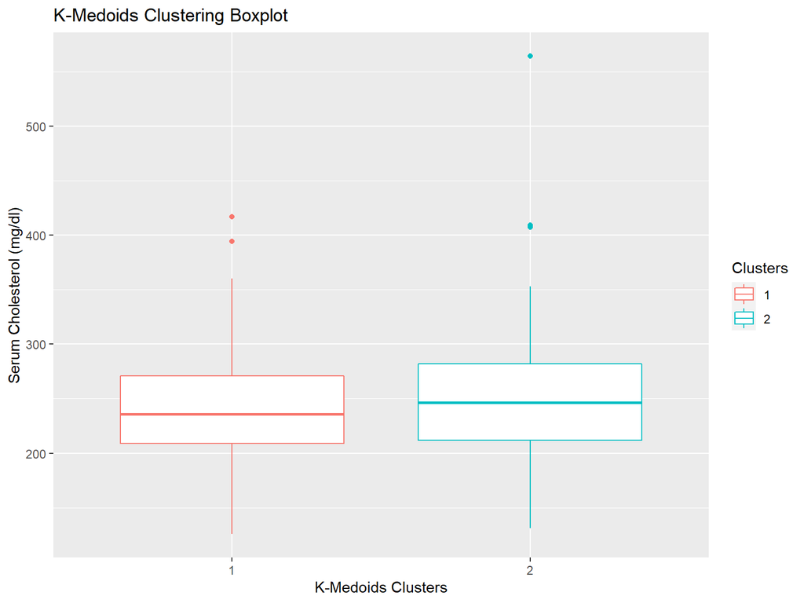

Figure 12: A Above we can see the box plot of the K-Medoids clusters. We can see that there are 2 clusters, with very similar medians and overlap in the IQR. This may be attributed to K-Medoids ability to handle outliers and noise within the data better than K-means and hierarchical clustering. With this, we may not see enough differentiation in our data to provide meanful clusters medically.

### Hierarchical Clusters

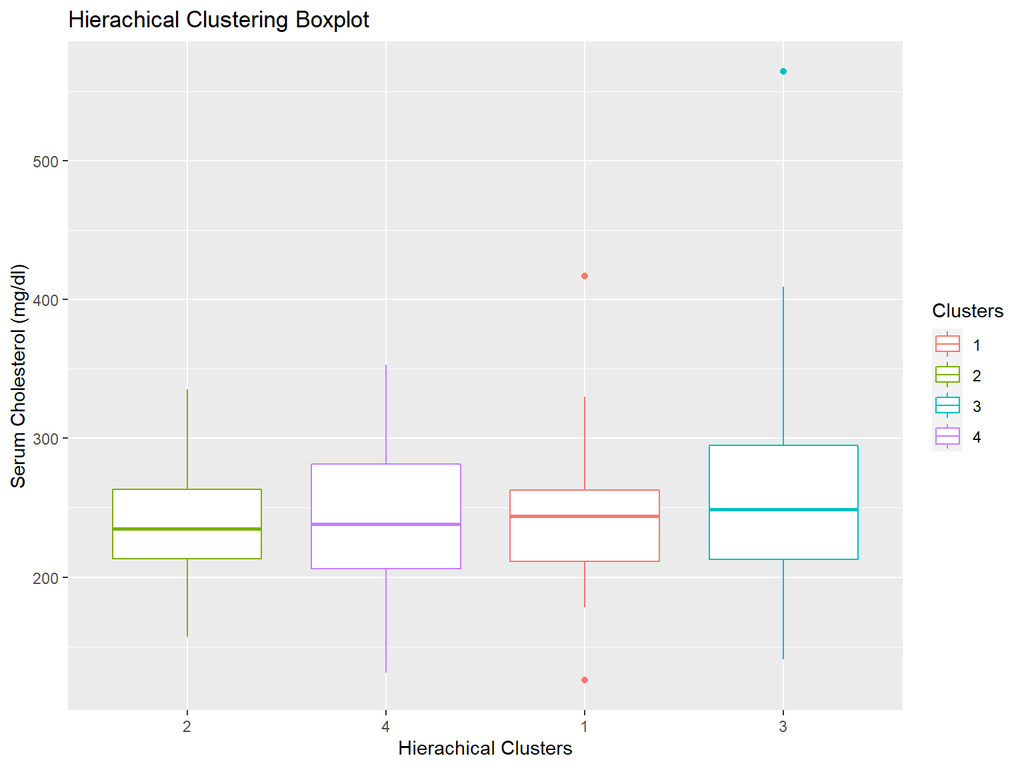

Figure 13: Above we can see the box plot of the Hierarchical clusters. We can see that there are 4 clusters, each with a distinct increasing median among the clusters, however we see significant overlap among the IQR. This may be in part driven by the extreme values that we see in clusters one and three.

### Discussion

Given that clustering does not start with an objective in mind, it is not surprising that our clustering methods when optimized did not come to the same conclusion on the category labels as the medical community. My expectation was that Hierarchical Clustering would come the closest as it produces a hierarchy of clusters, which would fit well with our “Desirable, Borderline, High” categories. While we did see a solid delineation in the median of each cluster, we saw significant overlap in the IQR of the cholesterol levels of each cluster.

The other surprise in this area was the K-Means clustering. While it produced 8 clusters, there is a very apparent upward trend in the median of the clusters. This may suggest that there are some other factors that would break out the cholesterol level into more detail.

Given my expectation of Hierarchical clustering and the surprise of K-means clustering, I am going to re-run each cluster with 3 defined clusters. Typically this would not be done, but given that we are comparing our data targets, I am curious how each method compares to our medical professional categories.

#### K-Means Re-Run

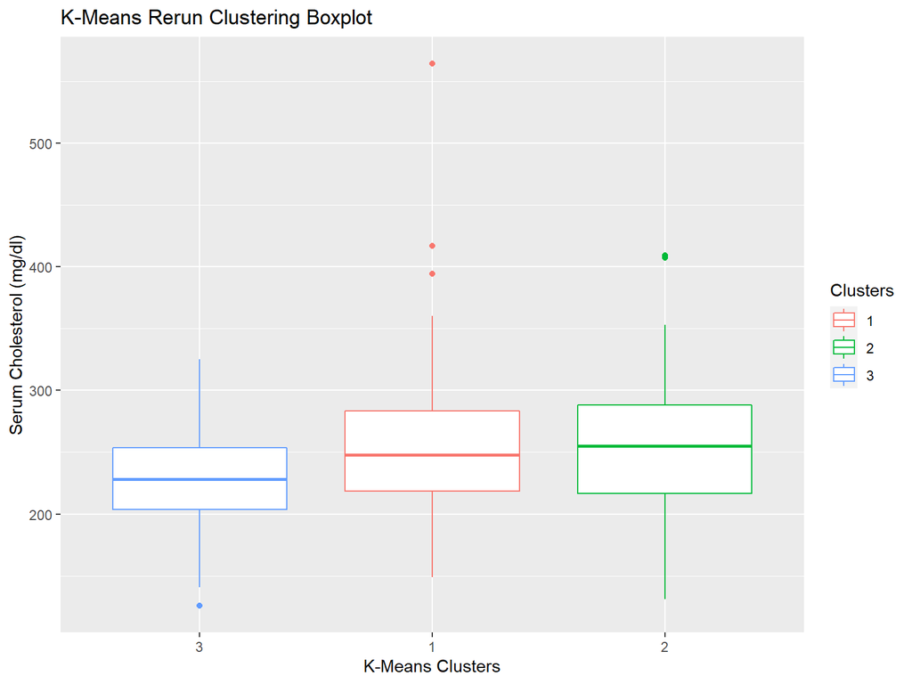

Figure 14: Above we can see the boxplot of the K-Means rerun at 3 set clusters. We can see there is a similar delineation among the medians, but that the middle and higher median share a lot of the same IQR. This may be attributed to the extreme values in cluster one causing the IQR to be stretched.

#### Hierarchical Re-Run

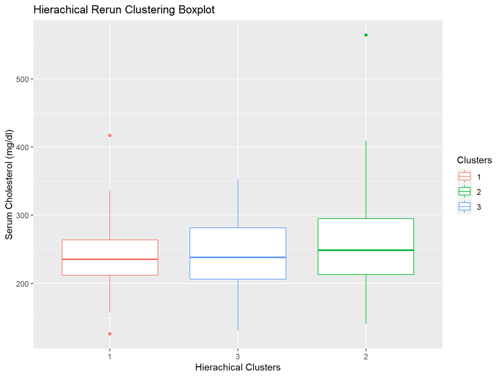